# Reproducible Research

Calvin Hutto

June 19, 2016

## Downloading and Initial Processing of Data

Here we download the activity dataset from the UCI data repository.

```r
if(!file.exists("getdata-projectfiles-UCI HAR Dataset.zip")) {
  temp <- tempfile()
  download.file("http://d396qusza40orc.cloudfront.net/repdata%2Fdata%2Factivity.zip",temp)
  unzip(temp)
  unlink(temp)
}

data <- read.csv("activity.csv")
```

## Initial Data Visualization

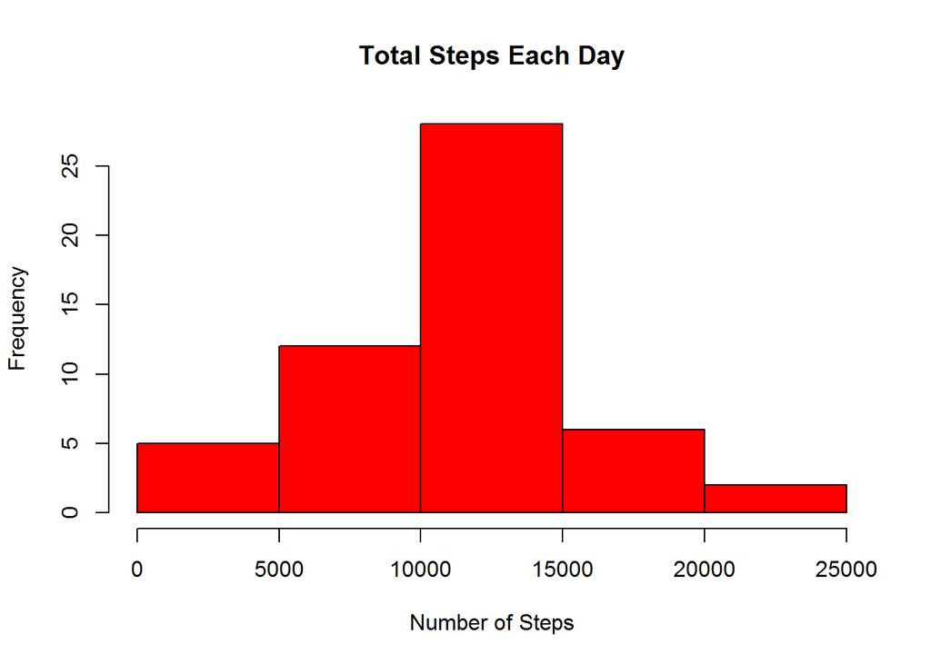

```r
steps_by_day <- aggregate(steps ~ date, data, sum)
hist(steps_by_day$steps, main = paste("Total Steps Each Day"), col="red", xlab="Number of Steps")
```

```r
mean1 <- mean(steps_by_day$steps)
median1 <- median(steps_by_day$steps)
```

## Determining Steps Based on 5 Minute Intervals

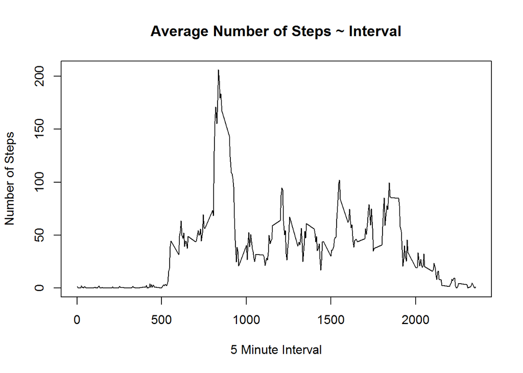

```r
steps_by_interval <- aggregate(steps ~ interval, data, mean)
plot(steps_by_interval$interval,steps_by_interval$steps, type="l", xlab="5 Minute Interval", ylab="Number of Steps",main="Average Number of Steps ~ Interval")
```

```r
max <- steps_by_interval[which.max(steps_by_interval$steps),1]
```

## Imputing Data

I used the mice package in order to impute the missing data in the frame. The below code analyzes the data frame for NAs and imputes them. The data indicate 2304 NAs within the steps variable in the data frame.

```
## mice 2.25 2015-11-09
```

```
##       date interval steps
## 15264    1        1     1    0
##  2304    1        1     0    1
##          0        0  2304 2304
```

```r
tempData <- mice(data,m=5,maxit=50,meth='pmm',seed=500)
summary(tempData)
```

```
## Multiply imputed data set
## Call:
## mice(data = data, m = 5, method = "pmm", maxit = 50, seed = 500)
## Number of multiple imputations:  5
## Missing cells per column:
##    steps     date interval
##     2304        0        0
## Imputation methods:
##    steps     date interval
##    "pmm"    "pmm"    "pmm"
## VisitSequence:
## steps
##     1
## PredictorMatrix:
##          steps date interval
## steps        0    1        1
## date         0    0        0
## interval     0    0        0
## Random generator seed value:  500
```

```r
completedData <- complete(tempData,1)
steps_by_day1 <- aggregate(steps ~ date, completedData, sum)
mean2 <- mean(steps_by_day1$steps)
median2 <- median(steps_by_day1$steps)
```

With the addition of the imputed data, the mean was adjusted down from 10766.19 to 10716.41 and the median was adjusted lower from 10765 to 10600. The additon of the imputed data had realatively minimal impact on the results especially for the purposes of our research.

## Weekend Analysis

The code below allows us to analyze weekend data and determine if there are differences in steps during the week versus during the weekend.

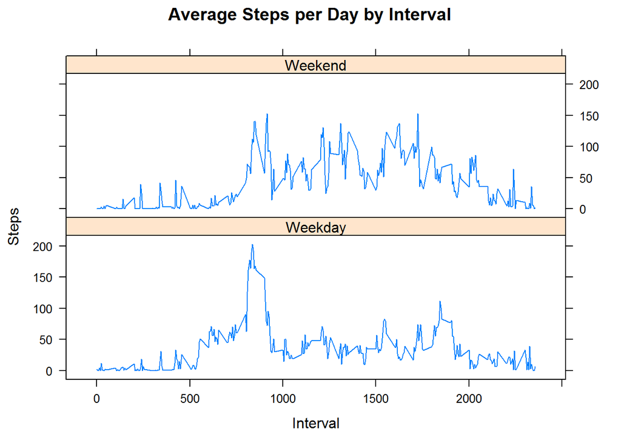

```r
weekdays <- c("Monday", "Tuesday", "Wednesday", "Thursday",
              "Friday")
completedData$dow = as.factor(ifelse(is.element(weekdays(as.Date(completedData$date)),weekdays), "Weekday", "Weekend"))

steps_by_interval_i <- aggregate(steps ~ interval + dow, completedData, mean)

library(lattice)
xyplot(steps_by_interval_i$steps ~ steps_by_interval_i$interval|steps_by_interval_i$dow, main="Average Steps per Day by Interval",xlab="Interval", ylab="Steps",layout=c(1,2), type="l")
```

The time series line graphs indicate an increased number of steps early in the day and then a marked decrease for the majority of the work day during the workweek. On the other hand, the weekend graph indicates less severe spikes and a more stable level of an elevated number of steps throughout the day.